# Dirty Spreadsheet Data

Patrick Kelly

2/13/2020

[Click Here](https://towardsdatascience.com/microsoft-excel-in-the-era-of-big-data-401e67ca28a5)“Excel in the era of big data”

# Spreadsheets

Most people with computers use them. But few use them well. Introduced in 1980, VisiCalc was the first “killer” application for personal computers. Today there are many,many choices. Excel captures about 85% of the market. OPenOffice Calc and LibreOffice Calc are two popular platforms.

Question: At what grade level are spreadsheeet introduced in school? Probably not early enough.

Data scientists spend up to 80% of their time wrangling dirty data into a usable format. This drudgery could be greatly reduced if people who present data in spreadsheets are taught that humans and computers have different requirements for interpretability.

Here is a data format that humans can understand.

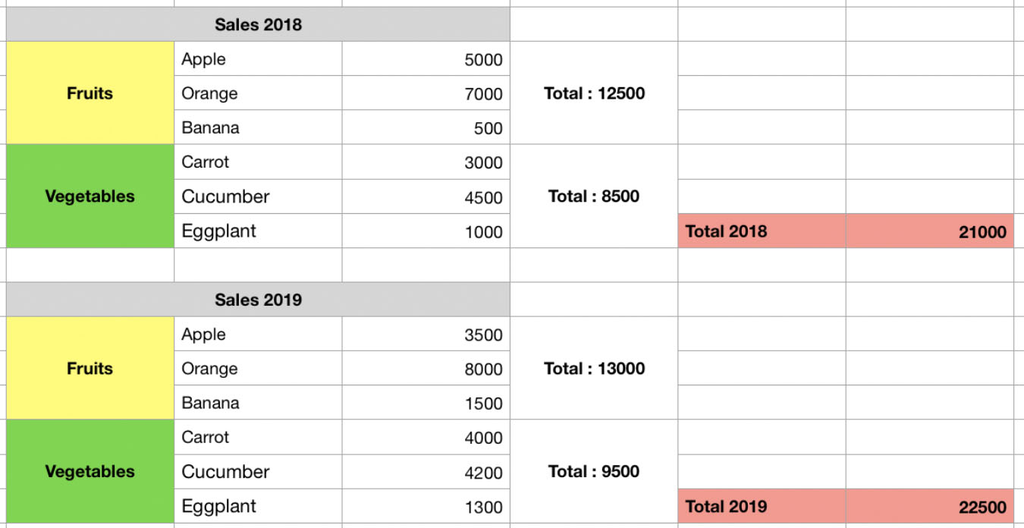

Human Version

And here is a format of the same data that computers can understand.

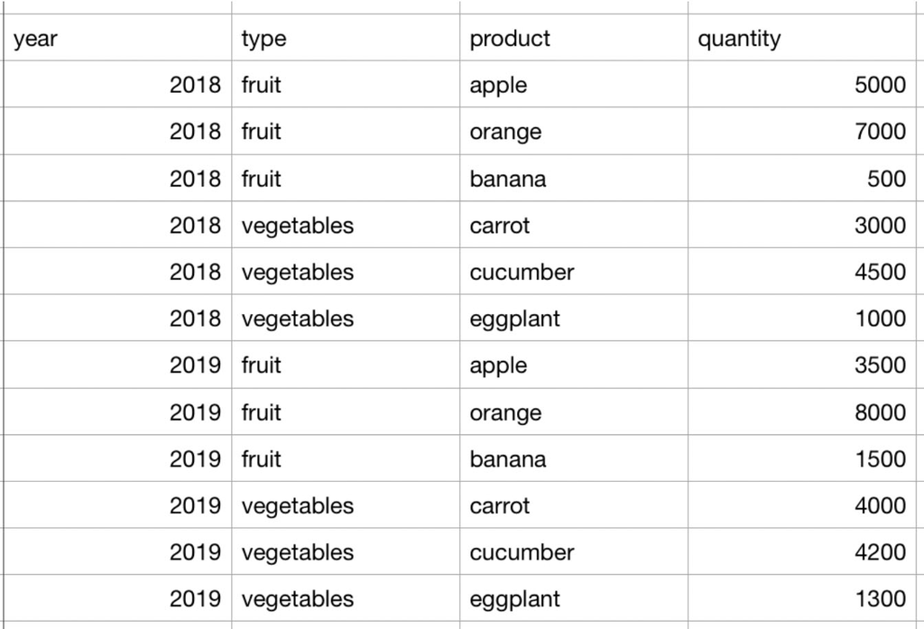

Computer Version

Thequestion is: How do we get from Dirty to Tidy?

The first challenge is scraping the data from the URL.

Here is how I did it.

1. Copy the image of the data with the screencapture function (Command+Shift+4) on the Mac.
2. Save to clipboard.
3. Load the image into Photoshop.
4. Save to a jpg file.

[Click Here](https://www.onlineocr.net)“Online OCR”

5. Transform the file from jpg to xlsx.
   1. Online Optical Character Recognition software
   2. Upload the jpg file and download the xlsx file.
   3. Load the xlsx filel into Excel.
   4. Save it to a csv file without any tweaking.
6. Now load the cv file into R.

```r
dirty <- read.csv("Dirty_Excel.csv",
        stringsAsFactors = FALSE)
dirty
```

```
##     Sales.2018    X           X.1        X.2   X.3
## 1        Apple 5000                             NA
## 2       Orange 7000 Total : 12500               NA
## 3       Banana  500                             NA
## 4       Carrot 3000                             NA
## 5     Cucumber 4500  Total : 8500               NA
## 6     Eggplant 1000               Total 2018 21000
## 7                NA                             NA
## 8   Sales 2019   NA                             NA
## 9        Apple 3500                             NA
## 10      Orange 8000 Total : 13000               NA
## 11      Banana 1500                             NA
## 12      Carrot 4000                             NA
## 13    Cucumber 4200  Total : 9500               NA
## 14    Eggplant 1300               Total 2019 22500
## 15               NA                             NA
## 16      Fruits   NA                             NA
## 17 Vegetable:"   NA                             NA
## 18           I   NA                             NA
## 19               NA                             NA
## 20      Fruits   NA                             NA
## 21           1   NA                             NA
## 22  Vegetables   NA                             NA
## 23           I   NA                             NA
```

### OUCH!. This is even dirtier than the original.

Why didn’t I clean the file in Excel. I want my wrangling to be reproducible by anyone. This is easy if all the transformations are done with R code.

### So now let’s do some tidying.

```r
tidy <- data.frame(year = c(rep(2018,6),
        rep(2019,6)))
tidy$type <-c(rep(dirty$Sales.2018[20],3),
   rep(dirty$Sales.2018[22],3),
   rep(dirty$Sales.2018[20],3),
  rep(dirty$Sales.2018[22],3))
tidy$product <- c(dirty$Sales.2018[1:6],
    dirty$Sales.2018[9:14])
tidy$quantity <- c(dirty$X[1:6],
    dirty$X[9:14])
tidy
```

```
##    year       type  product quantity
## 1  2018     Fruits    Apple     5000
## 2  2018     Fruits   Orange     7000
## 3  2018     Fruits   Banana      500
## 4  2018 Vegetables   Carrot     3000
## 5  2018 Vegetables Cucumber     4500
## 6  2018 Vegetables Eggplant     1000
## 7  2019     Fruits    Apple     3500
## 8  2019     Fruits   Orange     8000
## 9  2019     Fruits   Banana     1500
## 10 2019 Vegetables   Carrot     4000
## 11 2019 Vegetables Cucumber     4200
## 12 2019 Vegetables Eggplant     1300
```

### Exploratory Data Anaalysis (EDA)

```r
dim(tidy)
```

```
## [1] 12  4
```

```r
names(tidy)
```

```
## [1] "year"     "type"     "product"  "quantity"
```

```r
anyNA(tidy)
```

```
## [1] FALSE
```

```r
str(tidy)
```

```
## 'data.frame':    12 obs. of  4 variables:
##  $ year    : num  2018 2018 2018 2018 2018 ...
##  $ type    : chr  "Fruits" "Fruits" "Fruits" "Vegetables" ...
##  $ product : chr  "Apple" "Orange" "Banana" "Carrot" ...
##  $ quantity: int  5000 7000 500 3000 4500 1000 3500 8000 1500 4000 ...
```

```r
summary(tidy)
```

```
##       year          type             product             quantity
##  Min.   :2018   Length:12          Length:12          Min.   : 500
##  1st Qu.:2018   Class :character   Class :character   1st Qu.:1450
##  Median :2018   Mode  :character   Mode  :character   Median :3750
##  Mean   :2018                                         Mean   :3625
##  3rd Qu.:2019                                         3rd Qu.:4625
##  Max.   :2019                                         Max.   :8000
```

### Now for some analysis

```r
suppressMessages(library(dplyr))
suppressMessages(library(formattable))
by_group <- tidy %>% group_by(year,type)
table_1 <- by_group %>% summarize(total = sum(quantity))
formattable(table_1, align =c("c","c","c"))
```

| year | type | total |
| --- | --- | --- |
| 2018 | Fruits | 12500 |
| 2018 | Vegetables | 8500 |
| 2019 | Fruits | 13000 |
| 2019 | Vegetables | 9500 |

```r
by_year <- tidy %>% group_by(year)
table_2 <- by_year %>% summarize(total = sum(quantity))
formattable(table_2, align =c("c","c"))
```

| year | total |
| --- | --- |
| 2018 | 21000 |
| 2019 | 22500 |

[Click Here](https://www.littlemissdata.com/blog/prettytables)" Using Formattable"

[figure not shown]

```r
library(linguisticsdown)
library(htmlwidgets)
voila <- "voila.gif"
include_graphics2(voila)
```

# Chose dite…chose faite.